# Assignment 6 - Split-plot randomization

Author

COMFORT ADEGBENRO

# 1 Introduction

This assignment will ask you to conduct a split-plot RCBD randomization.

For that, you will first need to watch (and code along with) the following split-plot randomization video:

- split-plot randomization: https://youtu.be/rXTp3Vw_770?si=MajBK1aZ221orfpa&t=3401 (starts at 00:56:41, watch till end, about 50-min total)
- The partial script for the video above is in our GitHub repository, 04-classcode, **02-13_spp_randomization_partial.qmd**.

**AFTER watching the video and developing the code in class**, then start working on this HW assignment.

The different sections representing what we did in class were left in the script to provide you a scaffold to start from.

# 2 Instructions

- Move this script into the `code` subfolder of your `05_spp` project folder
- On this script, fill your name under the `title` section of the YAML

# 3 Goal of this assignment

The goal is this assignment is for you to **design a split-plot RCBD design applicable to your area of study**.

This could be from your own experience, an example from the literature, or something you come up entirely on your own (as long as it makes sense).

In the headings below, you will answer a couple of questions related to study objectives and treatment design, and then move on to randomize your study, create a plot layout, and export the designed table to file.

# 4 Setup

Here is where we load the packages we will use.  
Make sure to load each package in the chunk below.

```r
library(tidyverse)
library(janitor)
```

# 5 Treatment design

## 5.1 Objectives

Write here what are the objectives of the study you are designing. Remember that objectives are closely connected with your treatment design, so whatever you say are your objectives should carry through on your choice of treatment factors and levels.

**- The objective of this study is to assess the effect of different irrigation regimes and cotton cultivars on the yield of cotton.**

## 5.2 Treatment design explanation

Here is where you explain your treatment design, including the name of the treatment factors, their levels (don’t forget to include units), and which is the whole-plot treatment factor and which one is the split-plot treatment factor.

**This study has two treatment factors; hence, it will be a 2-way factorial split-plot.** The treatment factors and levels are:

1. **Whole-plot treatment factor:** irrigation with 2 levels: *well watered and dryland*
2. **Split-plot treatment factor:** cultivar with 3 levels: *DP 2038, DG 3799, DP 2131*

Additionally, for the purpose of this study, we will have 4 blocks. Hence, the total expected experimental unit is 24.

## 5.3 Code

Here develop the code to setup your design (like in class).

# 6 Split-plot in RCBD

## 6.1 WP randomization

Here, we will randomize the whole-plot treatment factor which is irrigation to the blocks.

```r
# set seed to ensure results are same always

set.seed(77)

# cross the whole plot trt (irrigation) with block

irr_rand = crossing(irrigation = c("well watered", "dryland"),
                    block = 1:4) %>%
  arrange(block) %>% # to arrange the replicated whole plot treatment by the block

  # randomize levels of irrigation with each block
  group_by(block) %>%
  mutate(irrigation = sample(irrigation)) %>%

  # assign plot numbers to the whole plots
  ungroup() %>%
  mutate(wplot = c(101:102,
                   201:202,
                   301:302,
                   401:402))

irr_rand
```

```
# A tibble: 8 × 3
  irrigation   block wplot
  <chr>        <int> <int>
1 well watered     1   101
2 dryland          1   102
3 dryland          2   201
4 well watered     2   202
5 dryland          3   301
6 well watered     3   302
7 well watered     4   401
8 dryland          4   402
```

## 6.2 SP randomization

Next we create the sub-plot or split-plot treatment and randomize within the whole plot treatment.

```r
cult_rand = crossing(cultivar = c("DP 2038", "DG 3799", "DP 2131"),
                     wplot = irr_rand$wplot) %>%

  # arrange by wplot for clarity
  arrange(wplot) %>%

  # next randomize the cultivar treatment within each whole plot
  group_by(wplot) %>%
  mutate(cultivar= sample(cultivar)) %>%

  # assign unique plot numbers to the split-plots
  ungroup() %>%
  mutate(splot = c(111:116,
                   211:216,
                   311:316,
                   411:416))

head(cult_rand)
```

```
# A tibble: 6 × 3
  cultivar wplot splot
  <chr>    <int> <int>
1 DP 2038    101   111
2 DG 3799    101   112
3 DP 2131    101   113
4 DP 2038    102   114
5 DP 2131    102   115
6 DG 3799    102   116
```

## 6.3 Joining WP and SP into one object

The whole plot and split plot are then brought together.

```r
irr_cult_spp = irr_rand %>%
  right_join(cult_rand) %>%

  # add a column for treatment name
  mutate(trtname =
           paste0(
    str_sub(irrigation, 1, 1),
    "-",
    str_replace_all(cultivar, " ", "")
    ))

head(irr_cult_spp, 3)
```

```
# A tibble: 3 × 6
  irrigation   block wplot cultivar splot trtname
  <chr>        <int> <int> <chr>    <int> <chr>
1 well watered     1   101 DP 2038    111 w-DP2038
2 well watered     1   101 DG 3799    112 w-DG3799
3 well watered     1   101 DP 2131    113 w-DP2131
```

Then check to see if a block contains all treatments.

```r
irr_cult_spp %>%
  filter(block == 3)
```

```
# A tibble: 6 × 6
  irrigation   block wplot cultivar splot trtname
  <chr>        <int> <int> <chr>    <int> <chr>
1 dryland          3   301 DG 3799    311 d-DG3799
2 dryland          3   301 DP 2131    312 d-DP2131
3 dryland          3   301 DP 2038    313 d-DP2038
4 well watered     3   302 DP 2131    314 w-DP2131
5 well watered     3   302 DG 3799    315 w-DG3799
6 well watered     3   302 DP 2038    316 w-DP2038
```

## 6.4 Plot layout

First add rows, columns and labels for creating the layout.

```r
irr_cult_layout = irr_cult_spp %>%
  # Defining number of rows and columns in the field for plotting purposes
  mutate(row = rep(1:4, each = 6)) %>%
  mutate(col = rep(seq(from = 1,
                       to = 6, #total number of treatments,
                       by = 1),
                   times = 4 #total number of blocks
  )) %>%
  # Creating plot and trtname labels for plotting
  mutate(label = paste0(splot, "\n", trtname))


head(irr_cult_layout, 3)
```

```
# A tibble: 3 × 9
  irrigation   block wplot cultivar splot trtname    row   col label
  <chr>        <int> <int> <chr>    <int> <chr>    <int> <dbl> <chr>
1 well watered     1   101 DP 2038    111 w-DP2038     1     1 "111\nw-DP2038"
2 well watered     1   101 DG 3799    112 w-DG3799     1     2 "112\nw-DG3799"
3 well watered     1   101 DP 2131    113 w-DP2131     1     3 "113\nw-DP2131"
```

Then, create the plot layout for visualization using ggplot.

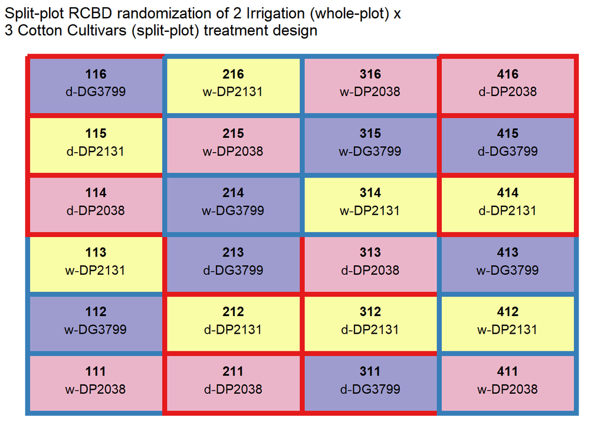

```r
ggplot(data = irr_cult_layout, aes(x= row,
                                   y= col)) +
  geom_tile(aes(fill = cultivar),
            color = "black",
            show.legend = FALSE) +
  scale_fill_viridis_d(alpha = 0.4, option = "plasma") +
  geom_tile(aes(colour = irrigation),
            fill = NA,
            show.legend = FALSE,
            linewidth = 2,
            linetype = 1
            ) +
  scale_color_brewer(palette = "Set1") +
  geom_text(aes(label = splot), fontface = "bold", vjust = -.8)+
  geom_text(aes(label = trtname), vjust = 1)+
  labs(title = " Split-plot RCBD randomization of 2 Irrigation (whole-plot) x \n 3 Cotton Cultivars (split-plot) treatment design") +
  theme_void()
```

# 7 Exporting to file

1. Export layout as data file in csv file format.

```r
irr_cult_layout %>%
  # Rearranging columns
  dplyr::select(block, wplot, irrigation,
                splot, cultivar,
                trtname) %>%
  write_csv("../output/irr_cult_randomization_table.csv")
```

2. Export layout as image in png format.

```r
ggsave("../output/irr_cult_layoutmap.png",
       width = 6,
       height = 5,
       bg = "white")
```

# 8 Submitting your work

Once you have developed all the code and answers, make sure to Render this quarto file.

**Notes on rendering**:

- Make sure to render your work and inspect how the final html look like.
- If it does not look professional for whatever reason, then fix the issue, re-render it, recheck.
- Only send me your work once your html file looks professional.
  - **DO NOT** delete the file’s heading levels (# and ##). They set up the proper heading 1 and 2 levels, and I use them to guide my grading.
  - If a given chunk is also outputting warnings or messages, inhibit this behavior by changing the chunk options `message` and `warning` to `FALSE` (I’ll demo this in a moment).
  - If, after rendered, 2 lines of text are connected and you wish to “break line” between them, add 2 extra spaces after the first one (I’lld demo this in a moment).

After rendering, an .html file will be created on your `code` folder.

Rename this file to `Assignment-06-spp-LASTNAME.html`.

For ex., mine would be `Assignment-06-spp-Bastos.html`.

Submit your work by uploading the **html** file to **eLC Assigment #6 - Split-plot randomization** by Feb 20 11:59 pm.